# December 2025 Newsletter

| **AP-LS Monthly Newsletter** |
| --- |

| **Facebook \| Blue Sky \| LinkedIn** |
| --- |

[figure not shown]

**Welcome to the December** **2025**

**American Psychology-Law Society (AP-LS) Newsletter**

Our monthly Newsletter provides information about activities, upcoming events, and resources to connect the psychology-law community.

AP-LS aspires to excel as a valuable, effective, and influential organization advancing the science of psychology-law and the translation of psychology-law knowledge into practice and policy.

[figure not shown]

## **Interested in showcasing your work at APA’s annual convention?**

[figure not shown]

Submit a proposal! We are accepting proposals from NOW until **Wednesday, January 14**. Presenting at APA 2026 is a great way to share your work with other psychologists, enhance your CV, and build your reputation.

Do you know colleagues that should speak at APA 2026? Please help us spread the word! Great presenters help us deliver a great event.

APA 2026 will be held August 6–8 in Washington DC. To learn more about the Convention, visit **https://convention.apa.org**. For questions, reach out to the Co-Chairs at (**apaconference@ap-ls.org)**.

Please consider serving as a proposal reviewer—we welcome student reviewers! Visit **https://tinyurl.com/Div41APA2026Reviewers** to sign up.

Conference Co-Chairs:

Krystia Reed, J.D., Ph.D., University of Texas at El Paso, (**kmreed2@utep.edu**)

Amor Correa, Ph.D., UT Southwestern Medical Center, (**amor.correa@utsouthwestern.edu**)

## **AP-LS 2026 Pre-conference Workshop Descriptions and Grants**

The AP-LS Continuing Education (CE) Committee is pleased to offer 10 grants to students and/or early career psychologists (defined as 10 years or less since last terminal degree was awarded) to attend pre-conference CE workshops. For the latest information about the pre-conference workshops and the conference, please check the **AP-LS conference website**. For information about the pre-conference workshops, please see **here**.  
To apply for a pre-conference grant (which covers the workshop registration fee), please complete the **application** by **Sunday, January 11****th****, 2026, 11:59 PST.** Grant recipients will be notified by January 27th (prior to the early registration rate deadline). Note: if you have already registered for a workshop, you can still apply and receive a refund for your registration fee.

Contact Sara Millspaugh, Ph.D., at (**ce@ap-ls.org**) with any questions. We look forward to receiving your applications!

## **Seeking Nominees: AP-LS Executive Committee Positions**

**Due by Friday, January 16, 2026**

In mid-April, an election will be held to fill the Division 41 positions of **President-Elect**, **Secretary**, and **Member-at-Large**. We are seeking nominations for these positions. Nominees must be a member of Division 41. Self-nominations are welcome. If you are nominating someone for the election slate, please ensure that they are willing to run if they are selected to be on the ballot.

The Society welcomes applications from AP-LS members who represent the full range of areas of interest within the broad intersection of psychology and law. We particularly welcome those whose vision includes an awareness of the challenges and opportunities faced by the Society’s mission to "enhance well-being, justice, and human rights through the science and practice of psychology in legal contexts."

All nominations are due by **Friday, January 16, 2026**.

The following materials must be submitted in a single PDF to our nominations portal:

- CV
- Letter(s) in support of the nominee
- Statement of interest (for self-nominations)

If you have an interest in one of these positions and have questions, we encourage you to speak with any member of the Nominations & Awards Committee (listed below).

Christian Meissner (**cmeissner@iastate.edu**), Chair & Past-President

Randy Salekin (**rsalekin@ua.edu**), Member & President

Virginia Barger Rioja (**Vibarber@hotmail.com**), Member & President-Elect

Jason Cantone (**cantone@gmail.com**), Member

Sarah Miller (**Sarah.L.Miller@maine.gov**), Member

Lavita Nadkarni (**lavita.nadkarni@du.edu**), Member

Kyle Scherr (**scher1kc@cmich.edu**), Member

# 2025 American Academy of Forensic Psychology Distinguished Contribution to Forensic Psychology Award

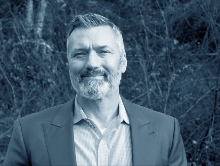

Dr. Daniel Murrie has been selected as the recipient of the 2025 American Academy of Forensic Psychology Distinguished Contribution to Forensic Psychology Award. This prestigious recognition reflects Dr. Murrie’s impact on forensic psychology and celebrates his exemplary record of service, scholarship, and leadership. Please join us in congratulating Dr. Murrie! More about Dr. Murrie's accomplishments can be found **HERE**.

# **Trial by Expert:**

**How Mental Health Evidence Shaped the Depp v. Heard (2022) Verdict**

**Molly Sickels & Tess M.S. Neal**

Expert witnesses have become a familiar presence not just in courtrooms, but in our everyday media diets. From true-crime podcasts to live-streamed trials, the public is increasingly exposed to the mechanics of legal proceedings—and to the experts who help shape them. Few cases illustrate this better than the 2022 defamation trial between Hollywood actors Johnny Depp and Amber Heard. Broadcast live to millions and followed by a surge of online commentary, memes, and even a Netflix documentary, the case featured a parade of expert witnesses whose testimony played a pivotal role in the outcome of the case. This article summarizes the mental health expert testimony in the trial, highlighting how mental health professionals were used by both legal teams to advance competing narratives. Drawing on original court documents and trial transcripts, we describe the testimony and opinions provided by the four psychological and psychiatric expert witnesses in the case. As such, we offer readers an overview of how mental health expertise was mobilized in a highly publicized legal setting – one that continues to shape public perceptions of mental health and the justice system. Read more **HERE**.

# **AP-LS Legal Update**

In July 2025, the Food and Drug Administration (FDA) issued warning letters to manufactures, consumers, and healthcare professionals outlining the deleterious effects of a widely unknown opioid: 7-hydroxymitragynine or 7-OH-MG. In the past few years, 7-OH-MG has not only been implemented in many overtly creative yet harmful ways, but it has been widely sold through gas stations, smoke shops, and Internet retailers. In this Legal Update, we seek to (1) define 7-OH-MG, (2) explain the FDA’s current perspective on 7-OH-MG, (3) outline the inherent issues associated with conflicting federal and state regulation of 7-OH-MG, (4) determine how this conflict might impact proactive behavioral health practices, and (5) identify the clinical-forensic implications as 7-OH-MG use becomes more prevalent. Read more **HERE**.

**2025 APA Apportionment Ballot Election**

You will be receiving or may have received your 2025 APA Apportionment Ballot Election, which determines how many seats each Division gets on Council. Division 41 has enjoyed two seats over the years. There are important decisions made on the Council floor which affect members of Division 41. Kindly consider supporting the Division by awarding as many votes as you can to us. The email subject line is: 2025 APA Apportionment Ballot Election.

Thank you,

Jennifer Groscup & Lavita Nadkarni, Council Representatives/ American Psychology-Law Society (Division 41)

Randy Salekin, President , American Psychology-Law Society (Division 41)

# **🏆 Defended Your Dissertation in 2025?**

Apply for the AP-LS Dissertation Award and be recognized for outstanding scholarship! Winners will be invited to share their work at the 2026 AP-LS Annual Conference. Submit your dissertation and supporting documents via the **AP-LS Dissertation Award Google Form** by **December 31**. For more information, visit **AP-LS Dissertation Awards webpage** or contact Alicia Nijdam-Jones (**alicia.nijdam-jones@umanitoba.ca**).

# **Caregiving Grants for AP-LS 2026**

The  APLS Professional Development of Women (PDW) Committee is thrilled to offer  Caregiving Grants of $250-$700 for 20-30 attendees of AP-LS 2026 in Reno, Nevada. We will give priority to first authors, presenters, students, and early career professionals. This grant is open to any AP-LS member (student and non-student) who serves as a caregiver in any capacity (e.g., child, parent). Funds can be used for any caregiving needs that arise during the conference, including needs at the conference or at home. Please apply using this link: **https://forms.gle/uMV4hKh5R4Hq7vco7**

Deadline to apply: **December 31, 2025.** We will notify grantees in late January 2026. Please contact PDW Chair, Sarah Fishel (**srp2yc@uvahealth.org**) with any questions

# **Outstanding Teaching and Mentoring in the Field of Psychology and Law: Call for Nominations**

This is a reminder that nominations for outstanding teaching and mentoring awards are due by the end of the day on **December 15, 2025**. These awards recognize teaching excellence in the field of psychology and law in a variety of contexts, specifically through the Outstanding Teaching and Mentoring Award and the Early Career Teaching and Mentoring Award.

For more information about the awards, eligibility, and how to nominate yourself or others, please click: **Teaching and Mentoring Awards**

This year the TTC Committee is specifically soliciting nominations for individuals who have taught or mentored undergraduate or terminal Master's students (i.e., Category 1).

Winners will be announced at the 2026 AP-LS Conference. Award recipients receive $500, a plaque at the AP-LS conference, and the option to serve as a guest columnist for the AP-LS Newsletter.

Please note, in the previous announcement, the email address for nomination was incorrect. Please use (**ttc@ap-ls.org**). For more information, please visit **https://ap-ls.org/awards/awards/teachingaward**

**REMINDER: Webinars: Learning from Lived Experience**

**SAVE THE DATE: January 28, 2026 (3:00 EST / 12:00 PST)**

These are part of the Presidential Initiative from Past-President Daniel Murrie.

The **mission of AP-LS** is “to enhance well-being, justice, and human rights through the application of psychological science and practice in legal contexts.” Our members often bring substantial clinical and scholarly expertise to this important mission. But another critical source of expertise in enhancing well-being, justice, and human rights is the expertise of persons with lived experience.

How might we better learn from those with lived experience? How might we collaborate on scholarship, policy, or clinical services in ways that honor their rights, dignity, and genuine expertise? To begin considering these questions, a series of webinars will share examples of fruitful collaborations that rely on experts with lived experience. Our webinars in May of 2025 addressed lived experience in clinical services and training, as well as informing policy. This session is more specific to research.

**Incorporating Lived Experience into Psychology-Law Research**

Join us for a 90-minute webinar on strategies for meaningfully incorporating the voices of people with lived experience (PWLE) in research related to the criminal legal system and substance use. Presenters will outline the benefits of engaging PWLE, introduce a practical framework grounded in community-based participatory research (CBPR), share real-world case studies, and offer actionable guidance for AP-LS researchers. Following a series of presentations, attendees will have the opportunity to engage in an open panel discussion. This session is designed for researchers across career stages and offers continuing education credit.

Please save the date if interested. A registration link will be forthcoming.

# **Diversity in Psychology and Law Research Awards**

The Diversity in Psychology and Law Research Award is sponsored by the Broadening Representation, Inclusion, Diversity, and Global Equity (BRIDGE) committee of the American Psychology-Law Society (APA, Div-41).

The award is intended to support student research on psycholegal issues related to diversity or conducted by individuals from underrepresented groups.

The purpose of the award is to promote diversity within the American Psychology-Law Society by supporting student research on psycholegal issues related to diversity as well as research by students from underrepresented groups. Projects are eligible for consideration for this award if they investigate topics related to psychology, law, diversity, and/or multiculturalism (e.g., research pertaining to psycholegal issues on race, gender, culture, sexual orientation, etc.), or if the principal investigator is a member of an underrepresented group, including racial and ethnic minorities, first-generation college students, LGBT individuals, and students with disabilities. Consistent with the mission of the BRIDGE Committee, these awards are intended to facilitate the research of individuals from groups that are underrepresented in AP-LS, as well as research about issues of potential interest and importance to such groups.

Each year the BRIDGE Committee will award up to three grants in the amount of $2,000, with an option to divide two of the awards into two $1,000 mini-grants.

The deadline for applications is **January 15****th** **of 2026**.

Information on award eligibility and how to apply can be found at the web address below:

**https://ap-ls.org/awards/grants/diversityresearch**

# **Call for Book Proposals**

The American Psychology-Law Society invites proposals for new titles in its book series, which is now published by Oxford University Press. We publish authored and edited volumes on current issues at the intersection of psychology and law. Books are typically a state of the science synthesis of a body of existing research with implications for practice and/or policy. Authors and editors should have a substantial and recent track record of publication and/or practice in psychology or law, and at least one should hold a doctorate in psychology or closely related behavioral science. If you have a proposal for a new book in the series or you would simply like more information, please reach out to a member of the editorial team. We would be happy to discuss possible topics and fit for the series.

The editorial board members are:

- Monica Miller, Division 41 Book Series Editor (**mkmiller@unr.edu**)
- Monique Bowen, Division 41 Book Series Associate Editor (**mbowen2@antioch.edu**)
- Jemour Maddux, Division 41 Book Series Associate Editor (**jm@rule702.com**)

# **Request for proposals for Chapters and Essays**

Monica K. Miller, David DeMatteo, and Daniel Krauss are editors of the book series

“Advances in Psychology and Law,” which seeks to enhance understanding of the connections between these disciplines, present “state of the science” summaries for current researchers, and provide a starting point for scholars wanting to delve into a new topic of study by reading an up-to-date review chapter or brief essay on that topic. All areas of psychology (e.g., developmental, social, cognitive, clinical, neuroscience) and law (e.g., criminal, civil, contracts, property, family) are appropriate for inclusion.

Chapters and essays will be primarily reviews or meta-analyses. Although they might provide some data to illustrate a new phenomenon, they are not meant to be data-driven like a journal article. Review chapters and essays will be on particular topics relevant to psychology and law and will be of current interest to the field. Chapters (and especially essays) will typically summarize research on one particular topic, rather than focusing on the entire body of research in an area (e.g., focusing on the Weapon Focus effect rather than the entire body of eyewitness memory). **Chapters** will be relatively long (30-40 pages d.s.), which will allow authors to provide in depth analysis and take calculated risks (e.g., engaging in informed speculation about future research or the consequences of particular legal policies). **Essays** will be shorter (approximately 10 pages d.s.) because they discuss a topic that is new and/or has less previous research to synthesize.

The book series has an editorial board of distinguished scholars who are experts in various areas in psychology and law. The editorial board will offer guidance about the development of topics and serve as expert reviewers of chapters and essays. The editors strive to produce one volume in the series approximately every 12-18 months.

Overviews of the previous volumes can be viewed here to ensure topics have not been already included in the series and to see examples of chapters: **http://www.springer.com/series/11918?detailsPage=titles**

Submit an approximately 300 word description and title of your proposed topic and indicate if you want to write an essay or chapter. Specify both the legal component and the psychological component of your topic. Email submissions to Monica Miller at **(mkmiller@unr.edu**).

**Executive Committee**

| For more information or if you wish to contact a member of the AP-LS Executive Committee, details can be found **HERE.** |
| --- |

## **On The Job or Postdoc Market? AP-LS Job Postings**

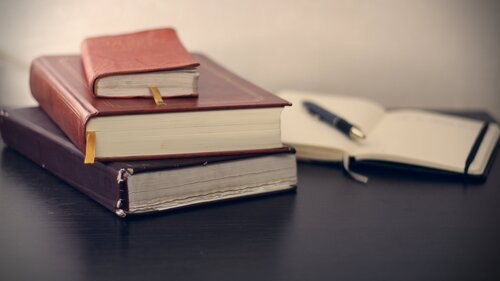

| Check out **AP-LS's Job Postings Page** for up-to-date information on available psychology-law positions. |
| --- |

| View Job Postings |
| --- |

## **Newsletter Editorial Board**

[output not shown]

[output not shown]

## **Membership Services**

[output not shown]

## **Newsletter Archives**

| **Archives of the newsletter are available at https://ap-ls.org/newsletter.** |
| --- |

| **American Psychology-Law Society** www.ap-ls.org \| (704) 456-7276 \| office@ap-ls.org |
| --- |

| *Copyright © American Psychology-Law Society* *Division 41 of the American Psychological Association All rights reserved.* |
| --- |